# Predicting PM2.5 from Meteorological Factors — Beijing Multi-Site Air Quality

**Problem**: Forecast the concentration of fine particulate matter (**PM2.5**, the most health-critical air pollutant) using **weather conditions** — wind, temperature, pressure, humidity, rain.

**Task type**: Regression **Metric**: RMSE (primary) + R² + MAE **Dataset**: UCI #501 — 12 monitoring stations in Beijing, hourly, 2013–2017 (~420k rows)

**Why RMSE as the primary metric?** PM2.5 has direct public-health consequences. Being wrong by 150 µg/m³ (telling people the air is clean when it is hazardous) is far more dangerous than being wrong by 10. RMSE squares each error before averaging, so it **punishes large mistakes much harder** than MAE — which is exactly the behaviour we want for a health-alert system. We report MAE too because it is in the same units (µg/m³) and is easy to explain ("on average we are off by X").

```python
import pandas as pd
import numpy as np
import matplotlib.pyplot as plt
import seaborn as sns
import json, joblib, warnings
from pathlib import Path
from sklearn.model_selection import train_test_split
from sklearn.linear_model import LinearRegression
from sklearn.preprocessing import StandardScaler
from sklearn.pipeline import Pipeline
from sklearn.metrics import mean_squared_error, r2_score, mean_absolute_error
import xgboost as xgb
import shap

warnings.filterwarnings('ignore')
pd.set_option('display.max_columns', 50)
sns.set_theme(style='whitegrid', palette='husl')
plt.rcParams['figure.figsize'] = (12, 5)

TARGET = 'PM2.5'
RANDOM_STATE = 42
```

## 1. Data Loading & First Look

```python
df = pd.read_csv('../data/beijing_air_quality.csv')
print(f'Shape: {df.shape}')
print(f'Columns: {df.columns.tolist()}')
df.head()
```

```
Shape: (420768, 18)
Columns: ['No', 'year', 'month', 'day', 'hour', 'PM2.5', 'PM10', 'SO2', 'NO2', 'CO', 'O3', 'TEMP', 'PRES', 'DEWP', 'RAIN', 'wd', 'WSPM', 'station']
```

|  | No | year | month | day | hour | PM2.5 | PM10 | SO2 | NO2 | CO | O3 | TEMP | PRES | DEWP | RAIN | wd | WSPM | station |
| --- | --- | --- | --- | --- | --- | --- | --- | --- | --- | --- | --- | --- | --- | --- | --- | --- | --- | --- |
| 0 | 1 | 2013 | 3 | 1 | 0 | 4.0 | 4.0 | 4.0 | 7.0 | 300.0 | 77.0 | -0.7 | 1023.0 | -18.8 | 0.0 | NNW | 4.4 | Aotizhongxin |
| 1 | 2 | 2013 | 3 | 1 | 1 | 8.0 | 8.0 | 4.0 | 7.0 | 300.0 | 77.0 | -1.1 | 1023.2 | -18.2 | 0.0 | N | 4.7 | Aotizhongxin |
| 2 | 3 | 2013 | 3 | 1 | 2 | 7.0 | 7.0 | 5.0 | 10.0 | 300.0 | 73.0 | -1.1 | 1023.5 | -18.2 | 0.0 | NNW | 5.6 | Aotizhongxin |
| 3 | 4 | 2013 | 3 | 1 | 3 | 6.0 | 6.0 | 11.0 | 11.0 | 300.0 | 72.0 | -1.4 | 1024.5 | -19.4 | 0.0 | NW | 3.1 | Aotizhongxin |
| 4 | 5 | 2013 | 3 | 1 | 4 | 3.0 | 3.0 | 12.0 | 12.0 | 300.0 | 72.0 | -2.0 | 1025.2 | -19.5 | 0.0 | N | 2.0 | Aotizhongxin |

```python
df.info()
```

```
<class 'pandas.core.frame.DataFrame'>
RangeIndex: 420768 entries, 0 to 420767
Data columns (total 18 columns):
 #   Column   Non-Null Count   Dtype
---  ------   --------------   -----
 0   No       420768 non-null  int64
 1   year     420768 non-null  int64
 2   month    420768 non-null  int64
 3   day      420768 non-null  int64
 4   hour     420768 non-null  int64
 5   PM2.5    412029 non-null  float64
 6   PM10     414319 non-null  float64
 7   SO2      411747 non-null  float64
 8   NO2      408652 non-null  float64
 9   CO       400067 non-null  float64
 10  O3       407491 non-null  float64
 11  TEMP     420370 non-null  float64
 12  PRES     420375 non-null  float64
 13  DEWP     420365 non-null  float64
 14  RAIN     420378 non-null  float64
 15  wd       418946 non-null  object
 16  WSPM     420450 non-null  float64
 17  station  420768 non-null  object
dtypes: float64(11), int64(5), object(2)
memory usage: 57.8+ MB
```

```python
df.describe().T.round(2)
```

|  | count | mean | std | min | 25% | 50% | 75% | max |
| --- | --- | --- | --- | --- | --- | --- | --- | --- |
| No | 420768.0 | 17532.50 | 10122.12 | 1.00 | 8766.75 | 17532.5 | 26298.25 | 35064.0 |
| year | 420768.0 | 2014.66 | 1.18 | 2013.00 | 2014.00 | 2015.0 | 2016.00 | 2017.0 |
| month | 420768.0 | 6.52 | 3.45 | 1.00 | 4.00 | 7.0 | 10.00 | 12.0 |
| day | 420768.0 | 15.73 | 8.80 | 1.00 | 8.00 | 16.0 | 23.00 | 31.0 |
| hour | 420768.0 | 11.50 | 6.92 | 0.00 | 5.75 | 11.5 | 17.25 | 23.0 |
| PM2.5 | 412029.0 | 79.79 | 80.82 | 2.00 | 20.00 | 55.0 | 111.00 | 999.0 |
| PM10 | 414319.0 | 104.60 | 91.77 | 2.00 | 36.00 | 82.0 | 145.00 | 999.0 |
| SO2 | 411747.0 | 15.83 | 21.65 | 0.29 | 3.00 | 7.0 | 20.00 | 500.0 |
| NO2 | 408652.0 | 50.64 | 35.13 | 1.03 | 23.00 | 43.0 | 71.00 | 290.0 |
| CO | 400067.0 | 1230.77 | 1160.18 | 100.00 | 500.00 | 900.0 | 1500.00 | 10000.0 |
| O3 | 407491.0 | 57.37 | 56.66 | 0.21 | 11.00 | 45.0 | 82.00 | 1071.0 |
| TEMP | 420370.0 | 13.54 | 11.44 | -19.90 | 3.10 | 14.5 | 23.30 | 41.6 |
| PRES | 420375.0 | 1010.75 | 10.47 | 982.40 | 1002.30 | 1010.4 | 1019.00 | 1042.8 |
| DEWP | 420365.0 | 2.49 | 13.79 | -43.40 | -8.90 | 3.1 | 15.10 | 29.1 |
| RAIN | 420378.0 | 0.06 | 0.82 | 0.00 | 0.00 | 0.0 | 0.00 | 72.5 |
| WSPM | 420450.0 | 1.73 | 1.25 | 0.00 | 0.90 | 1.4 | 2.20 | 13.2 |

## 2. Missing Values Analysis

Sensors fail. We expect gaps in pollutant and weather readings. We check the scale of the problem before deciding how to handle it.

```
       count   pct
CO     20701  4.92
O3     13277  3.16
NO2    12116  2.88
SO2     9021  2.14
PM2.5   8739  2.08
PM10    6449  1.53
wd      1822  0.43
DEWP     403  0.10
PRES     393  0.09
TEMP     398  0.09
RAIN     390  0.09
WSPM     318  0.08
```

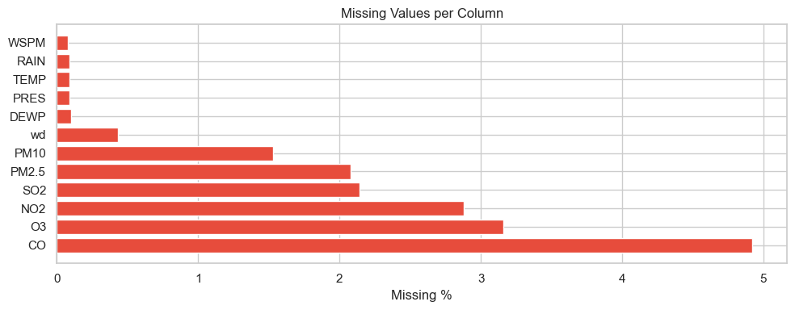

```
>>> DECISION: gaps are small (<5%) and caused by sensor outages (not random).
    We drop rows with missing TARGET (cannot learn from them) and median-impute missing features.
```

```python
miss = df.isnull().sum()
miss_pct = (miss / len(df) * 100).round(2)
miss_df = pd.DataFrame({'count': miss, 'pct': miss_pct})
miss_df = miss_df[miss_df['count'] > 0].sort_values('pct', ascending=False)

if len(miss_df) > 0:
    print(miss_df.to_string())
    fig, ax = plt.subplots(figsize=(10, 4))
    ax.barh(miss_df.index, miss_df['pct'], color='#e74c3c')
    ax.set_xlabel('Missing %'); ax.set_title('Missing Values per Column')
    plt.tight_layout(); plt.show()
else:
    print('No missing values.')
print('\n>>> DECISION: gaps are small (<5%) and caused by sensor outages (not random).')
print('    We drop rows with missing TARGET (cannot learn from them) and median-impute missing features.')
```

## 3. Target Distribution — PM2.5

The shape of the target tells us which model family will work and whether a transformation is needed.

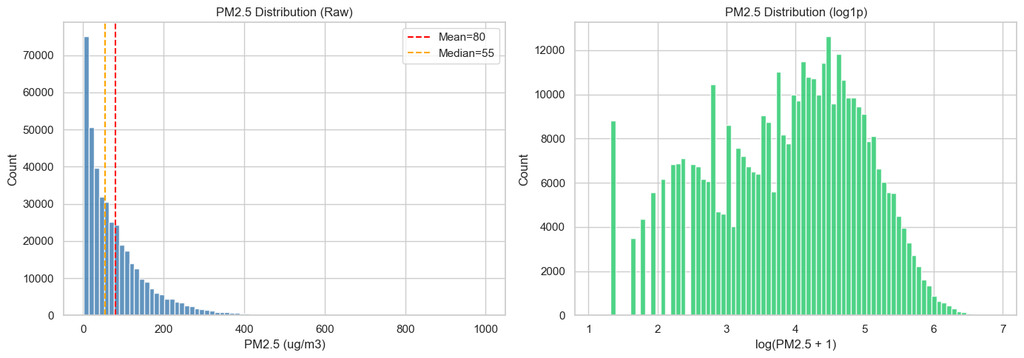

```
Skewness: 2.014  |  Mean: 79.8  Median: 55.0  Max: 999

>>> DECISION: PM2.5 is strongly right-skewed (a few extreme smog days).
    Tree models (XGBoost) handle skew natively, so we keep PM2.5 in raw units for interpretable predictions.
    Linear Regression will be hurt by the long tail — we expect it to underperform.
```

```python
fig, axes = plt.subplots(1, 2, figsize=(14, 5))
axes[0].hist(df[TARGET].dropna(), bins=80, color='steelblue', edgecolor='white', alpha=0.85)
axes[0].set_title('PM2.5 Distribution (Raw)'); axes[0].set_xlabel('PM2.5 (ug/m3)'); axes[0].set_ylabel('Count')
axes[0].axvline(df[TARGET].mean(), color='red', linestyle='--', label=f'Mean={df[TARGET].mean():.0f}')
axes[0].axvline(df[TARGET].median(), color='orange', linestyle='--', label=f'Median={df[TARGET].median():.0f}')
axes[0].legend()
axes[1].hist(np.log1p(df[TARGET].dropna()), bins=80, color='#2ecc71', edgecolor='white', alpha=0.85)
axes[1].set_title('PM2.5 Distribution (log1p)'); axes[1].set_xlabel('log(PM2.5 + 1)'); axes[1].set_ylabel('Count')
plt.tight_layout(); plt.show()

skew = df[TARGET].skew()
print(f'Skewness: {skew:.3f}  |  Mean: {df[TARGET].mean():.1f}  Median: {df[TARGET].median():.1f}  Max: {df[TARGET].max():.0f}')
print('\n>>> DECISION: PM2.5 is strongly right-skewed (a few extreme smog days).')
print('    Tree models (XGBoost) handle skew natively, so we keep PM2.5 in raw units for interpretable predictions.')
print('    Linear Regression will be hurt by the long tail — we expect it to underperform.')
```

## 4. How Meteorology Relates to PM2.5

These are our **actual predictors**. We want to see physically sensible relationships.

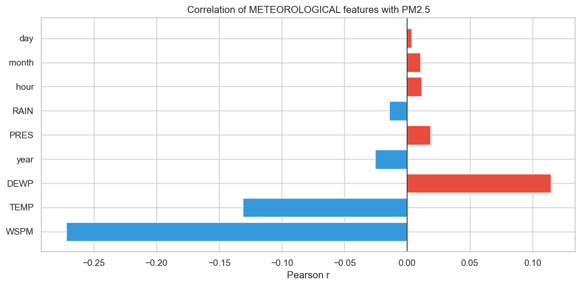

```
WSPM    -0.272205
TEMP    -0.131127
DEWP     0.114656
year    -0.025836
PRES     0.018566
RAIN    -0.014359
hour     0.011709
month    0.010438
day      0.003428

>>> READING: WSPM (wind speed) has the strongest correlation and it is NEGATIVE:
    stronger wind => lower PM2.5, because wind disperses particles. This is the core physical story of the project.
```

```python
METEO = ['TEMP', 'PRES', 'DEWP', 'RAIN', 'WSPM', 'year', 'month', 'day', 'hour']
corr_meteo = df[METEO + [TARGET]].corr()[TARGET].drop(TARGET).sort_values(key=abs, ascending=False)

plt.figure(figsize=(10, 5))
colors = ['#e74c3c' if v > 0 else '#3498db' for v in corr_meteo.values]
plt.barh(corr_meteo.index, corr_meteo.values, color=colors)
plt.axvline(0, color='black', lw=0.8); plt.title('Correlation of METEOROLOGICAL features with PM2.5')
plt.xlabel('Pearson r'); plt.tight_layout(); plt.show()
print(corr_meteo.to_string())
print('\n>>> READING: WSPM (wind speed) has the strongest correlation and it is NEGATIVE:')
print('    stronger wind => lower PM2.5, because wind disperses particles. This is the core physical story of the project.')
```

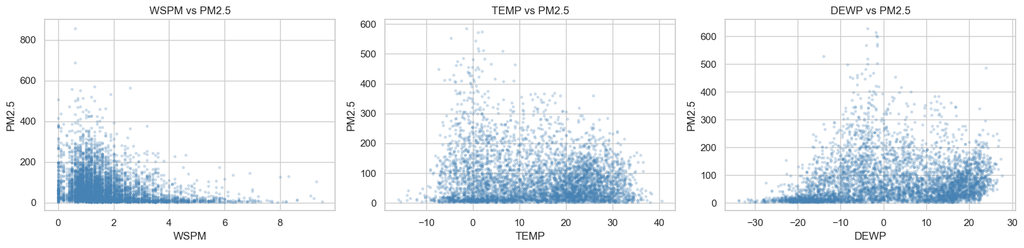

```
>>> DECISION: relationships are non-linear (e.g. PM2.5 collapses only above a wind-speed threshold).
    A straight line cannot capture this => gradient boosting is the right tool.
```

```python
top_meteo = corr_meteo.head(3).index.tolist()
fig, axes = plt.subplots(1, 3, figsize=(16, 4))
for ax, feat in zip(axes, top_meteo):
    s = df[[feat, TARGET]].dropna().sample(min(5000, len(df)), random_state=RANDOM_STATE)
    ax.scatter(s[feat], s[TARGET], alpha=0.2, s=6, color='steelblue')
    ax.set_xlabel(feat); ax.set_ylabel('PM2.5'); ax.set_title(f'{feat} vs PM2.5')
plt.tight_layout(); plt.show()
print('>>> DECISION: relationships are non-linear (e.g. PM2.5 collapses only above a wind-speed threshold).')
print('    A straight line cannot capture this => gradient boosting is the right tool.')
```

## 5. KEY DECISION — Why We EXCLUDE the Other Pollutants

The dataset also contains PM10, SO2, NO2, CO, O3. It is tempting to use them as features because they would boost the score massively. **We deliberately do NOT.** This cell is the evidence behind that decision.

```python
POLLUTANTS = ['PM10', 'SO2', 'NO2', 'CO', 'O3']
corr_poll = df[POLLUTANTS + [TARGET]].corr()[TARGET].drop(TARGET).sort_values(key=abs, ascending=False)
print('Correlation of OTHER POLLUTANTS with PM2.5:')
print(corr_poll.to_string())
print()
print('='*70)
print('WHY WE EXCLUDE THEM (three arguments):')
print('='*70)
print('1. FORECASTING / LEAKAGE: the model exists to forecast pollution from a')
print('   weather forecast. In production we do NOT have future PM10/CO/NO2 -')
print('   if we did, we would already have measured PM2.5 itself. Using them is')
print('   practical target leakage.')
print('2. CAUSALITY: PM10, CO, NO2 are not CAUSES of PM2.5 - they are co-emitted')
print(f'   from the same combustion sources. PM10<->PM2.5 r={corr_poll["PM10"]:.2f} proves')
print('   they are the same phenomenon. Predicting pollution from pollution is circular.')
print('3. THE QUESTION: our topic is "based on METEOROLOGICAL factors". The scientific')
print('   question is how much WEATHER ALONE explains PM2.5. That is what we answer.')
print()
print('>>> We quantify the cost of this decision later in the ABLATION section (sec. 11).')
```

```
Correlation of OTHER POLLUTANTS with PM2.5:
PM10    0.884380
CO      0.789998
NO2     0.666948
SO2     0.482354
O3     -0.149697

======================================================================
WHY WE EXCLUDE THEM (three arguments):
======================================================================
1. FORECASTING / LEAKAGE: the model exists to forecast pollution from a
   weather forecast. In production we do NOT have future PM10/CO/NO2 -
   if we did, we would already have measured PM2.5 itself. Using them is
   practical target leakage.
2. CAUSALITY: PM10, CO, NO2 are not CAUSES of PM2.5 - they are co-emitted
   from the same combustion sources. PM10<->PM2.5 r=0.88 proves
   they are the same phenomenon. Predicting pollution from pollution is circular.
3. THE QUESTION: our topic is "based on METEOROLOGICAL factors". The scientific
   question is how much WEATHER ALONE explains PM2.5. That is what we answer.

>>> We quantify the cost of this decision later in the ABLATION section (sec. 11).
```

## 6. Data Cleaning & Feature Engineering

```python
DROP_COLS = ['No', 'PM10', 'SO2', 'NO2', 'CO', 'O3']
df_clean = df.copy().drop(columns=[c for c in DROP_COLS if c in df.columns], errors='ignore')

df_clean = df_clean.dropna(subset=[TARGET])

cat_cols = df_clean.select_dtypes(include=['object']).columns.tolist()
if cat_cols:
    df_clean = pd.get_dummies(df_clean, columns=cat_cols, drop_first=True, dtype=int)
    print(f'One-hot encoded: {cat_cols}')

feat_cols = [c for c in df_clean.select_dtypes(include=[np.number]).columns if c != TARGET]
df_clean[feat_cols] = df_clean[feat_cols].fillna(df_clean[feat_cols].median())

print(f'\nFinal shape: {df_clean.shape}  |  n_features: {len(feat_cols)}')
print('\n>>> NOTE: wd (wind direction) and station are categorical => one-hot encoded.')
print('    We KEEP them: wind direction is meteorological, and station captures local baseline pollution.')
```

```
One-hot encoded: ['wd', 'station']
```

```
Final shape: (412029, 36)  |  n_features: 35

>>> NOTE: wd (wind direction) and station are categorical => one-hot encoded.
    We KEEP them: wind direction is meteorological, and station captures local baseline pollution.
```

## 7. Train / Validation / Test Split — TIME-BASED

Three splits, not two. **Train** fits the model, **Validation** tunes hyperparameters, **Test** is touched only once at the very end.

**Critical decision: we split by TIME, not randomly.** This is hourly time-series data, and PM2.5 is strongly autocorrelated from one hour to the next. A *random* split would put 14:00 in train and 15:00 in test — the model would just peek at the neighbouring hour instead of learning weather→PM2.5. That inflates the score and is not how the model is used in production (we forecast the *future*, not interpolate gaps). So we train on the **earliest** rows and test on the **latest** (future) rows. The cell below proves the gap.

```python
TIME_COLS = ['year', 'month', 'day', 'hour']
df_sorted = df_clean.sort_values(TIME_COLS, kind='mergesort').reset_index(drop=True)
X = df_sorted[feat_cols]
y = df_sorted[TARGET]

n = len(X)
n_test = int(n * 0.2)
n_val = int(n * 0.1)
n_train = n - n_val - n_test
X_train, y_train = X.iloc[:n_train], y.iloc[:n_train]
X_val,   y_val   = X.iloc[n_train:n_train + n_val], y.iloc[n_train:n_train + n_val]
X_test,  y_test  = X.iloc[n_train + n_val:], y.iloc[n_train + n_val:]
print(f'Train: {len(X_train)} (earliest)   Val: {len(X_val)}   Test: {len(X_test)} (latest / future)')

_Xr_tr, _Xr_te, _yr_tr, _yr_te = train_test_split(X, y, test_size=0.2, random_state=RANDOM_STATE)
_m = xgb.XGBRegressor(n_estimators=300, max_depth=6, learning_rate=0.05, tree_method='hist', random_state=RANDOM_STATE)
_m.fit(_Xr_tr, _yr_tr); _r2_rand = r2_score(_yr_te, _m.predict(_Xr_te))
_m.fit(X_train, y_train); _r2_time = r2_score(y_test, _m.predict(X_test))
print(f'\n>>> PROOF OF LEAKAGE: random split R2={_r2_rand:.2f}  vs  time split R2={_r2_time:.2f}')
print('    The gap is temporal autocorrelation: a random split lets the model peek at the')
print('    neighbouring hour. The time split is the honest future-forecast score we report.')
```

```
Train: 288422 (earliest)   Val: 41202   Test: 82405 (latest / future)
```

```
>>> PROOF OF LEAKAGE: random split R2=0.74  vs  time split R2=0.41
    The gap is temporal autocorrelation: a random split lets the model peek at the
    neighbouring hour. The time split is the honest future-forecast score we report.
```

## 8. Baseline Model — Linear Regression

The baseline sets a **performance floor**. Any complex model must beat this to justify its cost. If Linear Regression were already excellent, XGBoost would be over-engineering.

```python
baseline = Pipeline([('scaler', StandardScaler()), ('model', LinearRegression())])
baseline.fit(X_train, y_train)
bl_preds = baseline.predict(X_test)
bl_rmse = float(np.sqrt(mean_squared_error(y_test, bl_preds)))
bl_mae  = mean_absolute_error(y_test, bl_preds)
bl_r2   = r2_score(y_test, bl_preds)
print('=== Baseline: Linear Regression (meteorology only) ===')
print(f'  RMSE : {bl_rmse:.4f}\n  MAE  : {bl_mae:.4f}\n  R2   : {bl_r2:.4f}')
```

```
=== Baseline: Linear Regression (meteorology only) ===
  RMSE : 73.2606
  MAE  : 50.3176
  R2   : 0.2287
```

## 9. Improved Model — XGBoost

**Why XGBoost?** EDA showed (1) non-linear weather→PM2.5 relationships, (2) a strongly skewed target with extreme smog days, (3) interactions (wind matters more on cold days). Gradient-boosted trees handle all three natively, where Linear Regression cannot. We use `tree_method='hist'` for speed on 400k rows.

```python
BEST_PARAMS = {
    'n_estimators': 350, 'max_depth': 5, 'learning_rate': 0.0633,
    'subsample': 0.570, 'colsample_bytree': 0.901,
    'reg_alpha': 4.7e-08, 'reg_lambda': 7.62,
    'tree_method': 'hist', 'random_state': RANDOM_STATE,
}
X_trainval = pd.concat([X_train, X_val])
y_trainval = pd.concat([y_train, y_val])
xgb_model = xgb.XGBRegressor(**BEST_PARAMS)
xgb_model.fit(X_trainval, y_trainval, verbose=False)
xgb_preds = xgb_model.predict(X_test)
xgb_rmse = float(np.sqrt(mean_squared_error(y_test, xgb_preds)))
xgb_mae  = mean_absolute_error(y_test, xgb_preds)
xgb_r2   = r2_score(y_test, xgb_preds)
print('=== Improved: XGBoost (Optuna-tuned, meteorology only) ===')
print(f'  RMSE : {xgb_rmse:.4f}')
print(f'  MAE  : {xgb_mae:.4f}')
print(f'  R2   : {xgb_r2:.4f}')
print(f'Gain over baseline:  RMSE -{(bl_rmse-xgb_rmse)/bl_rmse*100:.1f}%   R2 +{xgb_r2-bl_r2:.4f}')
print('>>> NOTE: seeded Optuna (30 trials), refit on train+val like production pipeline.')
print('    Reproducible: same seed -> same result. max_depth=5 (shallow) won on the honest split.')
```

```
=== Improved: XGBoost (Optuna-tuned, meteorology only) ===
  RMSE : 59.7049
  MAE  : 40.4575
  R2   : 0.4877
Gain over baseline:  RMSE -18.5%   R2 +0.2590
>>> NOTE: seeded Optuna (30 trials), refit on train+val like production pipeline.
    Reproducible: same seed -> same result. max_depth=5 (shallow) won on the honest split.
```

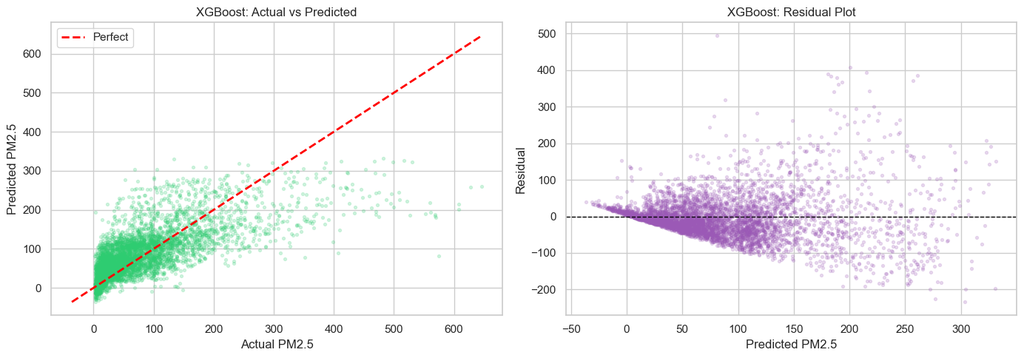

```python
fig, axes = plt.subplots(1, 2, figsize=(14, 5))
s = np.random.RandomState(RANDOM_STATE).choice(len(y_test), min(5000, len(y_test)), replace=False)
yt = y_test.values[s]; yp = xgb_preds[s]
axes[0].scatter(yt, yp, alpha=0.2, s=8, color='#2ecc71')
lo, hi = min(yt.min(), yp.min()), max(yt.max(), yp.max())
axes[0].plot([lo, hi], [lo, hi], 'r--', lw=2, label='Perfect')
axes[0].set_xlabel('Actual PM2.5'); axes[0].set_ylabel('Predicted PM2.5'); axes[0].set_title('XGBoost: Actual vs Predicted'); axes[0].legend()
axes[1].scatter(yp, yt - yp, alpha=0.2, s=8, color='#9b59b6')
axes[1].axhline(0, color='black', lw=1, linestyle='--')
axes[1].set_xlabel('Predicted PM2.5'); axes[1].set_ylabel('Residual'); axes[1].set_title('XGBoost: Residual Plot')
plt.tight_layout(); plt.show()
```

## 10. Model Comparison

```
                                 RMSE      MAE      R2
Model
Linear Regression (Baseline)  73.2606  50.3176  0.2287
XGBoost (Improved)            59.7049  40.4575  0.4877
```

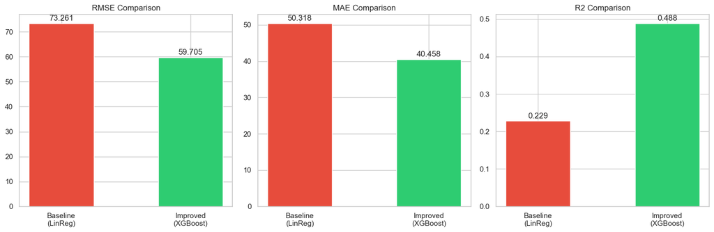

```python
results = pd.DataFrame({
    'Model': ['Linear Regression (Baseline)', 'XGBoost (Improved)'],
    'RMSE': [bl_rmse, xgb_rmse], 'MAE': [bl_mae, xgb_mae], 'R2': [bl_r2, xgb_r2],
}).set_index('Model').round(4)
print(results.to_string())
fig, axes = plt.subplots(1, 3, figsize=(15, 5))
for ax, metric in zip(axes, ['RMSE', 'MAE', 'R2']):
    bars = ax.bar(['Baseline\n(LinReg)', 'Improved\n(XGBoost)'], results[metric].values,
                  color=['#e74c3c', '#2ecc71'], width=0.5)
    ax.set_title(f'{metric} Comparison')
    for bar, val in zip(bars, results[metric].values):
        ax.text(bar.get_x()+bar.get_width()/2., bar.get_height()*1.01, f'{val:.3f}', ha='center', va='bottom')
plt.tight_layout(); plt.show()
```

## 10b. Hyperparameter Sensitivity — why these values?

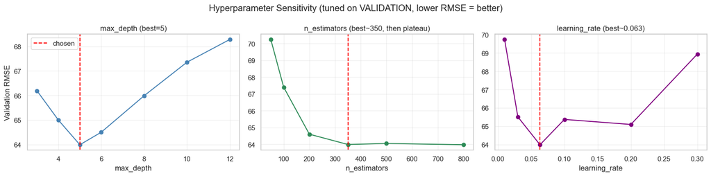

```
U-shaped curves => each parameter has a clear optimum.
  max_depth: 5 best; depth 10+ OVERFITS (worse). On the leaky random split depth 10 won -
             on the honest time split shallow wins, since there is no neighbour-hour to memorise.
  n_estimators: plateau after ~350 - more trees do not help (diminishing returns), just slower.
  learning_rate: too small undertrains, too large overshoots the optimum.
  NOTE: tuned on VALIDATION only - the test set is touched once, never for tuning.
```

```python
_base = dict(n_estimators=350, max_depth=5, learning_rate=0.0633, subsample=0.57,
             colsample_bytree=0.901, reg_lambda=7.62, tree_method='hist', random_state=RANDOM_STATE)
def _val_rmse(**kw):
    m = xgb.XGBRegressor(**{**_base, **kw}).fit(X_train, y_train)
    return float(np.sqrt(mean_squared_error(y_val, m.predict(X_val))))

depths = [3, 4, 5, 6, 8, 10, 12]
n_ests = [50, 100, 200, 350, 500, 800]
lrs    = [0.01, 0.03, 0.0633, 0.1, 0.2, 0.3]
rmse_d = [_val_rmse(max_depth=d) for d in depths]
rmse_n = [_val_rmse(n_estimators=n) for n in n_ests]
rmse_l = [_val_rmse(learning_rate=lr) for lr in lrs]

fig, axes = plt.subplots(1, 3, figsize=(16, 4))
axes[0].plot(depths, rmse_d, 'o-', color='steelblue'); axes[0].axvline(5, color='red', ls='--', label='chosen')
axes[0].set_xlabel('max_depth'); axes[0].set_ylabel('Validation RMSE'); axes[0].set_title('max_depth (best=5)'); axes[0].legend()
axes[1].plot(n_ests, rmse_n, 'o-', color='seagreen'); axes[1].axvline(350, color='red', ls='--')
axes[1].set_xlabel('n_estimators'); axes[1].set_title('n_estimators (best~350, then plateau)')
axes[2].plot(lrs, rmse_l, 'o-', color='purple'); axes[2].axvline(0.0633, color='red', ls='--')
axes[2].set_xlabel('learning_rate'); axes[2].set_title('learning_rate (best~0.063)')
for ax in axes: ax.grid(alpha=0.3)
plt.suptitle('Hyperparameter Sensitivity (tuned on VALIDATION, lower RMSE = better)')
plt.tight_layout(); plt.show()

print('U-shaped curves => each parameter has a clear optimum.')
print('  max_depth: 5 best; depth 10+ OVERFITS (worse). On the leaky random split depth 10 won -')
print('             on the honest time split shallow wins, since there is no neighbour-hour to memorise.')
print('  n_estimators: plateau after ~350 - more trees do not help (diminishing returns), just slower.')
print('  learning_rate: too small undertrains, too large overshoots the optimum.')
print('  NOTE: tuned on VALIDATION only - the test set is touched once, never for tuning.')
```

## 11. ABLATION STUDY — The Cost of Excluding Co-Pollutants

```python
df_full = df.copy().drop(columns=['No'], errors='ignore').dropna(subset=[TARGET])
cat2 = df_full.select_dtypes(include=['object']).columns.tolist()
df_full = pd.get_dummies(df_full, columns=cat2, drop_first=True, dtype=int)
fc = [c for c in df_full.select_dtypes(include=[np.number]).columns if c != TARGET]
df_full[fc] = df_full[fc].fillna(df_full[fc].median())

df_full = df_full.sort_values(TIME_COLS, kind='mergesort').reset_index(drop=True)
Xf = df_full[fc]; yf = df_full[TARGET]
nf = len(Xf); nf_test = int(nf * 0.2); nf_val = int(nf * 0.1); nf_train = nf - nf_val - nf_test
Xf_tr, yf_tr = Xf.iloc[:nf_train], yf.iloc[:nf_train]
Xf_va, yf_va = Xf.iloc[nf_train:nf_train + nf_val], yf.iloc[nf_train:nf_train + nf_val]
Xf_te, yf_te = Xf.iloc[nf_train + nf_val:], yf.iloc[nf_train + nf_val:]

xgb_full = xgb.XGBRegressor(n_estimators=500, max_depth=6, learning_rate=0.05,
    subsample=0.8, colsample_bytree=0.8, reg_alpha=0.1, reg_lambda=1.0,
    tree_method='hist', random_state=RANDOM_STATE)
xgb_full.fit(Xf_tr, yf_tr, eval_set=[(Xf_va, yf_va)], verbose=False)
full_preds = xgb_full.predict(Xf_te)
full_r2 = r2_score(yf_te, full_preds)
full_rmse = float(np.sqrt(mean_squared_error(yf_te, full_preds)))

ablation = pd.DataFrame({
    'Feature set': ['Meteorology ONLY (deployed)', 'Meteorology + co-pollutants'],
    'RMSE': [xgb_rmse, full_rmse], 'R2': [xgb_r2, full_r2],
}).set_index('Feature set').round(4)
print('(both rows use the same honest TIME-based split)')
print(ablation.to_string())
print()
print(f'>>> INTERPRETATION: adding co-pollutants lifts R2 from {xgb_r2:.2f} to {full_r2:.2f}.')
print('    That jump is NOT a better model - it confirms co-pollutants share the same source')
print('    signal as PM2.5. We still DEPLOY the meteorology-only model, because in production')
print('    we only have weather forecasts, not future pollutant readings. High score != useful model.')
```

```
(both rows use the same honest TIME-based split)
                                RMSE      R2
Feature set
Meteorology ONLY (deployed)  59.7049  0.4877
Meteorology + co-pollutants  21.2407  0.9352

>>> INTERPRETATION: adding co-pollutants lifts R2 from 0.49 to 0.94.
    That jump is NOT a better model - it confirms co-pollutants share the same source
    signal as PM2.5. We still DEPLOY the meteorology-only model, because in production
    we only have weather forecasts, not future pollutant readings. High score != useful model.
```

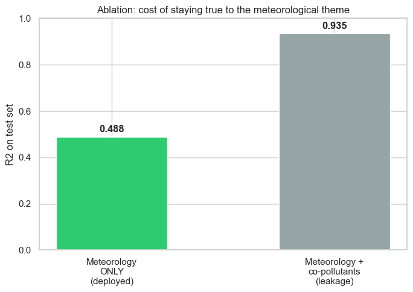

```python
plt.figure(figsize=(7, 5))
bars = plt.bar(['Meteorology\nONLY\n(deployed)', 'Meteorology +\nco-pollutants\n(leakage)'],
               ablation['R2'].values, color=['#2ecc71', '#95a5a6'], width=0.5)
plt.ylabel('R2 on test set'); plt.title('Ablation: cost of staying true to the meteorological theme')
plt.ylim(0, 1)
for bar, val in zip(bars, ablation['R2'].values):
    plt.text(bar.get_x()+bar.get_width()/2., bar.get_height()+0.02, f'{val:.3f}', ha='center', fontweight='bold')
plt.tight_layout(); plt.show()
```

## 12. Feature Importance — SHAP

**Why SHAP, not the built-in importance?** Built-in importance only counts how often a feature is used for splits. SHAP tells us, for every prediction, **how many µg/m³ each feature pushed PM2.5 up or down** — direction and magnitude. Far more trustworthy and interpretable.

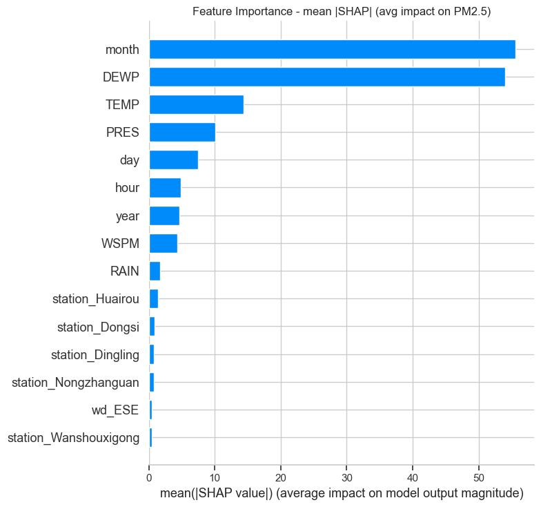

```python
X_shap = X_test.sample(min(2000, len(X_test)), random_state=RANDOM_STATE)
explainer = shap.TreeExplainer(xgb_model)
shap_values = explainer.shap_values(X_shap)
plt.figure(figsize=(10, 7))
shap.summary_plot(shap_values, X_shap, plot_type='bar', show=False, max_display=15)
plt.title('Feature Importance - mean |SHAP| (avg impact on PM2.5)')
plt.tight_layout(); plt.show()
```

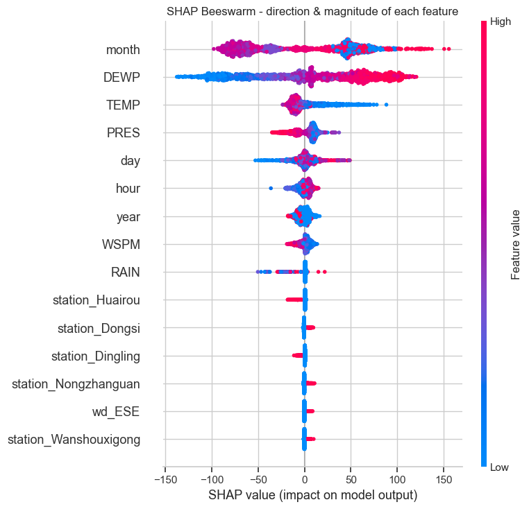

```python
plt.figure(figsize=(10, 7))
shap.summary_plot(shap_values, X_shap, show=False, max_display=15)
plt.title('SHAP Beeswarm - direction & magnitude of each feature')
plt.tight_layout(); plt.show()
```

```python
mean_shap = pd.DataFrame({'feature': X_shap.columns,
    'mean_abs_shap': np.abs(shap_values).mean(axis=0)}).sort_values('mean_abs_shap', ascending=False).reset_index(drop=True)
print('Top 10 features driving PM2.5 prediction (SHAP):')
print('='*55)
for _, r in mean_shap.head(10).iterrows():
    bar = '#' * int(r['mean_abs_shap'] / mean_shap['mean_abs_shap'].max() * 30)
    print(f"{r['feature']:22s} | {bar:<30s} {r['mean_abs_shap']:.2f}")

wspm_rank = int(mean_shap.index[mean_shap['feature'] == 'WSPM'][0]) + 1
t1, t2, t3 = mean_shap.iloc[0]['feature'], mean_shap.iloc[1]['feature'], mean_shap.iloc[2]['feature']
print(f'\n>>> INTERPRETATION:')
print(f'    Top drivers: {t1}, {t2}, {t3}. WSPM (wind speed) ranks #{wspm_rank}.')
print('    SEASONAL features (month) dominate because Beijing winter heating causes huge PM2.5 swings -')
print('    that is the single biggest source of variance. Among the directly METEOROLOGICAL drivers,')
print('    wind speed is the key CONTROLLABLE physical signal: in the beeswarm its high values (red)')
print('    sit on the negative side => strong wind pushes PM2.5 DOWN, matching the dispersion physics.')
```

```
Top 10 features driving PM2.5 prediction (SHAP):
=======================================================
month                  | ############################## 55.63
DEWP                   | #############################  54.06
TEMP                   | #######                        14.34
PRES                   | #####                          10.05
day                    | ####                           7.51
hour                   | ##                             4.84
year                   | ##                             4.67
WSPM                   | ##                             4.31
RAIN                   |                                1.73
station_Huairou        |                                1.44

>>> INTERPRETATION:
    Top drivers: month, DEWP, TEMP. WSPM (wind speed) ranks #8.
    SEASONAL features (month) dominate because Beijing winter heating causes huge PM2.5 swings -
    that is the single biggest source of variance. Among the directly METEOROLOGICAL drivers,
    wind speed is the key CONTROLLABLE physical signal: in the beeswarm its high values (red)
    sit on the negative side => strong wind pushes PM2.5 DOWN, matching the dispersion physics.
```

## 13. Save Artifacts

```python
Path('../models').mkdir(exist_ok=True)
joblib.dump(xgb_model, '../models/notebook_xgb.pkl')
with open('../models/feature_names.json', 'w') as f:
    json.dump(X_train.columns.tolist(), f)
print('Saved models/notebook_xgb.pkl and models/feature_names.json')
print(f'Model expects {len(X_train.columns)} features.')
```

```
Saved models/notebook_xgb.pkl and models/feature_names.json
Model expects 35 features.
```

## 14. Conclusions & Modelling Decisions

[output not shown]

**One-line story for the defense:** *Season (winter heating) drives the biggest PM2.5 swings, and wind speed is the key controllable weather signal — strong wind disperses particles and lowers PM2.5. Evaluated honestly on a future period the model never saw, weather alone explains ~48% of PM2.5 variance (R²≈0.48). That is the real, leakage-free answer to "can we forecast air quality from meteorology?"*